# ExtraaLearn Project

## Context

The EdTech industry has been surging in the past decade immensely, and according to a forecast, the Online Education market would be worth $286.62bn by 2023 with a compound annual growth rate (CAGR) of 10.26% from 2018 to 2023. The modern era of online education has enforced a lot in its growth and expansion beyond any limit. Due to having many dominant features like ease of information sharing, personalized learning experience, transparency of assessment, etc, it is now preferable to traditional education.

In the present scenario due to the Covid-19, the online education sector has witnessed rapid growth and is attracting a lot of new customers. Due to this rapid growth, many new companies have emerged in this industry. With the availability and ease of use of digital marketing resources, companies can reach out to a wider audience with their offerings. The customers who show interest in these offerings are termed as leads. There are various sources of obtaining leads for Edtech companies, like

- The customer interacts with the marketing front on social media or other online platforms.
- The customer browses the website/app and downloads the brochure
- The customer connects through emails for more information.

The company then nurtures these leads and tries to convert them to paid customers. For this, the representative from the organization connects with the lead on call or through email to share further details.

## Objective

ExtraaLearn is an initial stage startup that offers programs on cutting-edge technologies to students and professionals to help them upskill/reskill. With a large number of leads being generated on a regular basis, one of the issues faced by ExtraaLearn is to identify which of the leads are more likely to convert so that they can allocate resources accordingly. You, as a data scientist at ExtraaLearn, have been provided the leads data to:

- Analyze and build an ML model to help identify which leads are more likely to convert to paid customers,
- Find the factors driving the lead conversion process
- Create a profile of the leads which are likely to convert

## Data Description

The data contains the different attributes of leads and their interaction details with ExtraaLearn. The detailed data dictionary is given below.

**Data Dictionary**

- ID: ID of the lead
- age: Age of the lead
- current_occupation: Current occupation of the lead. Values include 'Professional','Unemployed',and 'Student'
- first_interaction: How did the lead first interacted with ExtraaLearn. Values include 'Website', 'Mobile App'
- profile_completed: What percentage of profile has been filled by the lead on the website/mobile app. Values include Low - (0-50%), Medium - (50-75%), High (75-100%)
- website_visits: How many times has a lead visited the website
- time_spent_on_website: Total time spent on the website
- page_views_per_visit: Average number of pages on the website viewed during the visits.
- last_activity: Last interaction between the lead and ExtraaLearn.
  - Email Activity: Seeking for details about program through email, Representative shared information with lead like brochure of program , etc
  - Phone Activity: Had a Phone Conversation with representative, Had conversation over SMS with representative, etc
  - Website Activity: Interacted on live chat with representative, Updated profile on website, etc
- print_media_type1: Flag indicating whether the lead had seen the ad of ExtraaLearn in the Newspaper.
- print_media_type2: Flag indicating whether the lead had seen the ad of ExtraaLearn in the Magazine.
- digital_media: Flag indicating whether the lead had seen the ad of ExtraaLearn on the digital platforms.
- educational_channels: Flag indicating whether the lead had heard about ExtraaLearn in the education channels like online forums, discussion threads, educational websites, etc.
- referral: Flag indicating whether the lead had heard about ExtraaLearn through reference.
- status: Flag indicating whether the lead was converted to a paid customer or not.

## Importing necessary libraries and data

```python
import warnings

warnings.filterwarnings("ignore")
from statsmodels.tools.sm_exceptions import ConvergenceWarning

warnings.simplefilter("ignore", ConvergenceWarning)

# Libraries to help with reading and manipulating data

import pandas as pd
import numpy as np

# Library to split data
from sklearn.model_selection import train_test_split

# libaries to help with data visualization
import matplotlib.pyplot as plt
import seaborn as sns

# Removes the limit for the number of displayed columns
pd.set_option("display.max_columns", None)
# Sets the limit for the number of displayed rows
pd.set_option("display.max_rows", 200)
# setting the precision of floating numbers to 5 decimal points
pd.set_option("display.float_format", lambda x: "%.5f" % x)

# To build model for prediction
import statsmodels.stats.api as sms
from statsmodels.stats.outliers_influence import variance_inflation_factor
import statsmodels.api as sm
from statsmodels.tools.tools import add_constant
from sklearn.linear_model import LogisticRegression
from sklearn.tree import DecisionTreeClassifier
from sklearn import tree
from sklearn.ensemble import RandomForestClassifier

# To tune different models
from sklearn.model_selection import GridSearchCV


# To get diferent metric scores
import sklearn.metrics as metrics
from sklearn.metrics import (
    f1_score,
    accuracy_score,
    recall_score,
    precision_score,
    confusion_matrix,
    classification_report,
    roc_auc_score,
    precision_recall_curve,
    roc_curve,
    make_scorer,
)
```

## Data Overview

- Observations
- Sanity checks

```python
# Importing necessary libraries
import pandas as pd

# Load the data
data = pd.read_csv("ExtraaLearn.csv")

# Display the first few rows of the data
print("First few rows of the dataset:")
print(data.head())

# Display basic information about the data
print("\nBasic information about the dataset:")
print(data.info())

# Display basic statistics of the data
print("\nBasic statistics of the dataset:")
print(data.describe())

# Checking for missing values
print("\nMissing values in the dataset:")
print(data.isnull().sum())

# Checking for duplicates
print("\nDuplicate entries in the dataset:")
print(data.duplicated().sum())

# Checking the unique values in each categorical column
categorical_columns = ['current_occupation', 'first_interaction', 'profile_completed',
                       'last_activity', 'print_media_type1', 'print_media_type2',
                       'digital_media', 'educational_channels', 'referral', 'status']

print("\nUnique values in categorical columns:")
for col in categorical_columns:
    print(f"{col}: {data[col].unique()}")

# Checking the balance of the target variable
print("\nDistribution of target variable (status):")
print(data['status'].value_counts())
```

```
First few rows of the dataset:
       ID  age current_occupation first_interaction profile_completed  \
0  EXT001   57         Unemployed           Website              High
1  EXT002   56       Professional        Mobile App            Medium
2  EXT003   52       Professional           Website            Medium
3  EXT004   53         Unemployed           Website              High
4  EXT005   23            Student           Website              High

   website_visits  time_spent_on_website  page_views_per_visit  \
0               7                   1639               1.86100
1               2                     83               0.32000
2               3                    330               0.07400
3               4                    464               2.05700
4               4                    600              16.91400

      last_activity print_media_type1 print_media_type2 digital_media  \
0  Website Activity               Yes                No           Yes
1  Website Activity                No                No            No
2  Website Activity                No                No           Yes
3  Website Activity                No                No            No
4    Email Activity                No                No            No

  educational_channels referral  status
0                   No       No       1
1                  Yes       No       0
2                   No       No       0
3                   No       No       1
4                   No       No       0

Basic information about the dataset:
<class 'pandas.core.frame.DataFrame'>
RangeIndex: 4612 entries, 0 to 4611
Data columns (total 15 columns):
 #   Column                 Non-Null Count  Dtype
---  ------                 --------------  -----
 0   ID                     4612 non-null   object
 1   age                    4612 non-null   int64
 2   current_occupation     4612 non-null   object
 3   first_interaction      4612 non-null   object
 4   profile_completed      4612 non-null   object
```

[output cut: 58 more lines]

```
first_interaction: ['Website' 'Mobile App']
profile_completed: ['High' 'Medium' 'Low']
last_activity: ['Website Activity' 'Email Activity' 'Phone Activity']
print_media_type1: ['Yes' 'No']
print_media_type2: ['No' 'Yes']
digital_media: ['Yes' 'No']
educational_channels: ['No' 'Yes']
referral: ['No' 'Yes']
status: [1 0]

Distribution of target variable (status):
status
0    3235
1    1377
Name: count, dtype: int64
```

## Exploratory Data Analysis (EDA)

- EDA is an important part of any project involving data.
- It is important to investigate and understand the data better before building a model with it.
- A few questions have been mentioned below which will help you approach the analysis in the right manner and generate insights from the data.
- A thorough analysis of the data, in addition to the questions mentioned below, should be done.

**Questions**

1. Leads will have different expectations from the outcome of the course and the current occupation may play a key role in getting them to participate in the program. Find out how current occupation affects lead status.
2. The company's first impression on the customer must have an impact. Do the first channels of interaction have an impact on the lead status?
3. The company uses multiple modes to interact with prospects. Which way of interaction works best?
4. The company gets leads from various channels such as print media, digital media, referrals, etc. Which of these channels have the highest lead conversion rate?
5. People browsing the website or mobile application are generally required to create a profile by sharing their personal data before they can access additional information.Does having more details about a prospect increase the chances of conversion?

```
Conversion rate by current occupation:
  current_occupation  conversion_rate
0       Professional          0.35512
1            Student          0.11712
2         Unemployed          0.26579
```

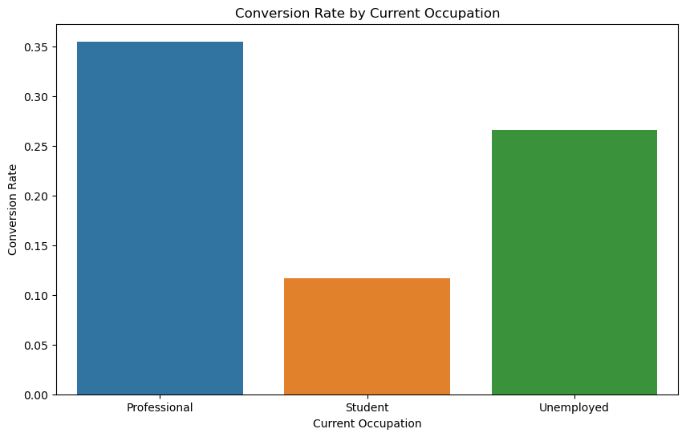

```python
# Importing necessary libraries for visualization
import matplotlib.pyplot as plt
import seaborn as sns

# Load the data
data = pd.read_csv("ExtraaLearn.csv")

# Calculate the conversion rate for each occupation
occupation_conversion = data.groupby('current_occupation')['status'].mean().reset_index()

# Rename columns for clarity
occupation_conversion.columns = ['current_occupation', 'conversion_rate']

# Display the conversion rate by occupation
print("Conversion rate by current occupation:")
print(occupation_conversion)

# Plot the conversion rate by occupation
plt.figure(figsize=(10, 6))
sns.barplot(x='current_occupation', y='conversion_rate', data=occupation_conversion)
plt.title('Conversion Rate by Current Occupation')
plt.xlabel('Current Occupation')
plt.ylabel('Conversion Rate')
plt.show()
```

```python
Comments made from the output of question 1:
The analysis of the conversion rates by current occupation reveals significant variations, with professionals
exhibiting the highest conversion rate at approximately 35.5%, followed by unemployed individuals at around 26.6%,
and students at about 11.7%. This suggests that professionals are more inclined to convert to paid customers,
possibly due to their proactive pursuit of career advancement opportunities. However, challenges may exist in
converting students, possibly due to financial constraints or perceived value proposition concerns. Nevertheless,
there remains a good opportunity to engage unemployed individuals, indicating potential for ExtraaLearn to offer
programs tailored to enhance their employability. Overall, understanding the impact of current occupation on lead
status provides valuable insights for optimizing marketing strategies and course offerings to maximize conversion
rates.
```

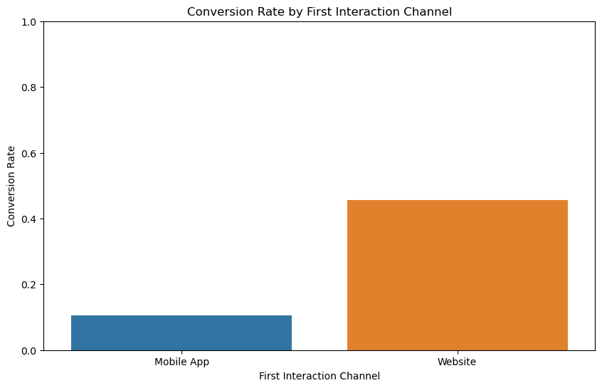

```python
import pandas as pd
import seaborn as sns
import matplotlib.pyplot as plt

# Load the data
data = pd.read_csv("ExtraaLearn.csv")

# Calculate the conversion rate for each first channel of interaction
interaction_conversion = data.groupby('first_interaction')['status'].mean().reset_index()
interaction_conversion.columns = ['first_interaction', 'conversion_rate']

# Plot the conversion rates
plt.figure(figsize=(10, 6))
sns.barplot(x='first_interaction', y='conversion_rate', data=interaction_conversion)
plt.title('Conversion Rate by First Interaction Channel')
plt.xlabel('First Interaction Channel')
plt.ylabel('Conversion Rate')
plt.ylim(0, 1)
plt.show()
```

```python
Comments made from the output of question 2: Based on the analysis, it appears that the first channels of
interaction do indeed have an impact on the lead status. The data suggests that leads who interact with the
company through the website are significantly more likely to convert to paid customers compared to those who
interact through the mobile app. This could imply that the website provides a more comprehensive and convincing
initial experience for potential customers, potentially offering easier access to information or a more
user-friendly interface. Consequently, ExtraaLearn may benefit from focusing more resources on optimizing the
website experience and leveraging it as a primary channel for lead engagement to maximize conversion rates.
```

```
Conversion rates for each mode of interaction:
      last_activity  conversion_rate
2  Website Activity          0.38455
0    Email Activity          0.30334
1    Phone Activity          0.21313
```

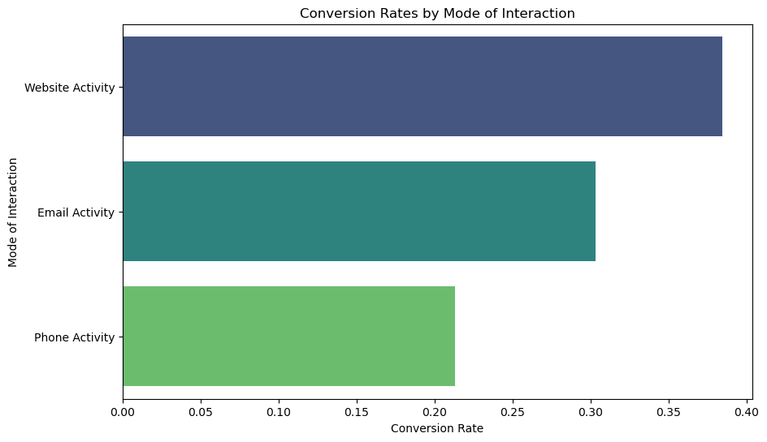

```python
# Importing necessary libraries
import pandas as pd
import matplotlib.pyplot as plt
import seaborn as sns

# Load the data
data = pd.read_csv("ExtraaLearn.csv")

# Calculate conversion rate for each mode of interaction
interaction_conversion = data.groupby('last_activity')['status'].mean().reset_index()
interaction_conversion.columns = ['last_activity', 'conversion_rate']

# Sort the conversion rates in descending order
interaction_conversion = interaction_conversion.sort_values(by='conversion_rate', ascending=False)

# Display the conversion rates
print("Conversion rates for each mode of interaction:")
print(interaction_conversion)

# Plot the conversion rates
plt.figure(figsize=(10, 6))
sns.barplot(x='conversion_rate', y='last_activity', data=interaction_conversion, palette='viridis')
plt.title('Conversion Rates by Mode of Interaction')
plt.xlabel('Conversion Rate')
plt.ylabel('Mode of Interaction')
plt.show()
```